# WHO_analysis

## Built in R packages

To further explore the relationshp between time and concentration between country, we decided to explore built in packages in RStudio and see which were relevant to our project. After careful research, we came across the “openair” package, which is particularly relevant to air pollutant data. Carslaw, D. C., & Ropkins, K. (2012). openair — An R package for air quality data analysis. Environmental Modelling & Software, 27–28, 52–61. https://doi.org/10.1016/j.envsoft.2011.09.008

Included in this package is TimePlot, which we decided to use to compare to our scatter plots. lLubridate is also used to deal with time handling

```r
#install.packages("openair")

library(openair)
library(dplyr)
library(lubridate)
```

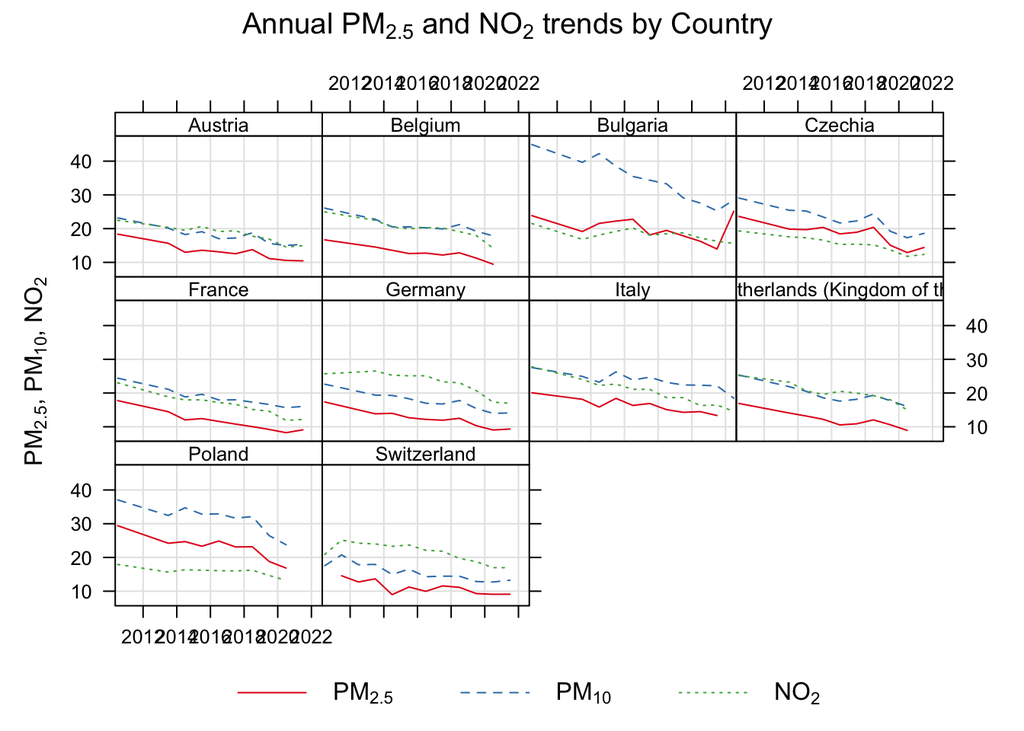

```r
data_openair_country= pm10_top_10 %>%
  filter(!is.na(year)) %>%
  group_by(country_name, year) %>%
  summarise(
    pm25 = mean(pm25_concentration, na.rm = TRUE),
    pm10 = mean(pm10_concentration, na.rm = TRUE),
    no2  = mean(no2_concentration, na.rm = TRUE),
    .groups = "drop"
  ) %>%
  mutate(date = ymd(paste0(year, "-06-30"))) %>%  # because of the nature of this package, we have to generate a date for each year
  select(date, country_name, pm25, pm10, no2)
timePlot(data_openair_country,pollutant = c("pm25", "pm10", "no2"),
         type = "country_name",
         main = "Annual pm25 and no2 trends by Country")
```

This creates a very clear visualisation of all 3 particle matter types, though the scale is harder to read, I believe these provide a clear insight into the trends, which are obviously negatively correlated.

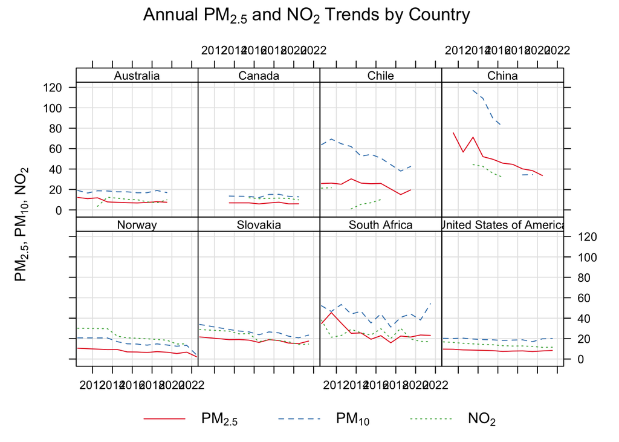

```r
library(openair)
library(dplyr)
library(lubridate)

data_openair_country= pm25_top_10 %>%
  filter(!is.na(year)) %>%
  group_by(country_name, year) %>%
  summarise(
    pm25 = mean(pm25_concentration, na.rm = TRUE),
    pm10 = mean(pm10_concentration, na.rm = TRUE),
    no2  = mean(no2_concentration, na.rm = TRUE),
    .groups = "drop"
  ) %>%
  mutate(date = ymd(paste0(year, "-06-30"))) %>%
  select(date, country_name, pm25, pm10, no2)
timePlot(data_openair_country,
         pollutant = c("pm25", "pm10", "no2"),
         type = "country_name",
         main = "Annual PM2.5 and NO2 Trends by Country")
```

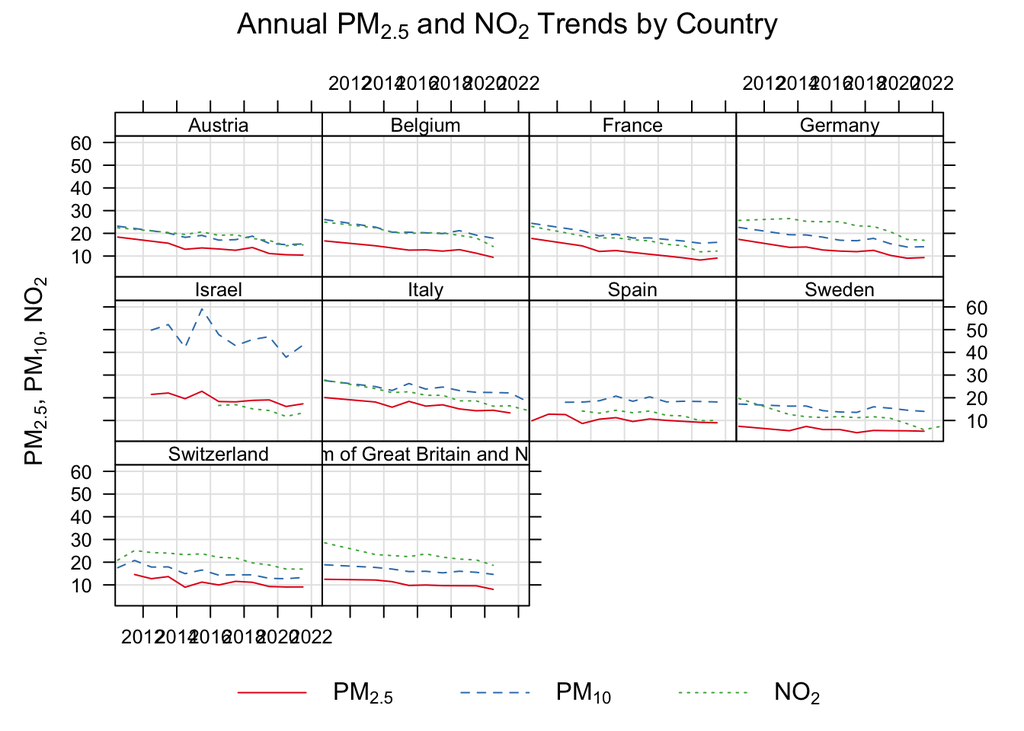

```r
library(openair)
library(dplyr)
library(lubridate)

data_openair_country=no2_top_10 %>%
  filter(!is.na(year)) %>%
  group_by(country_name, year) %>%
  summarise(
    pm25 = mean(pm25_concentration, na.rm = TRUE),
    pm10 = mean(pm10_concentration, na.rm = TRUE),
    no2  = mean(no2_concentration, na.rm = TRUE),
    .groups = "drop"
  ) %>%
  mutate(date = ymd(paste0(year, "-06-30"))) %>%
  select(date, country_name, pm25, pm10, no2)

timePlot(data_openair_country,
         pollutant = c("pm25", "pm10", "no2"),
         type = "country_name",
         main = "Annual PM2.5 and NO2 Trends by Country")
```

# Conclusion

After extensive exploration of our data, we can conclude that there is a general decline in pollutant concentrations over time in most European countries (from 2015 onwards). We explored 2 different methods when creating time plots, by using ggplot and by using built in R packages. The ggplots were easier to read when picking out key information such as year and specific concentration. However for exploring trends, openair was very useful as it provided a clear visual representation of all concentrations- making it easy to compare between countries and across different particle types.